# P1-ethanol

Aidan Burk

2024-04-28

## Introduction

gas_mileage_data.csv consists of data that Professor Jarad Niemi collected on 347 trips made on his 2011 Toyota Sienna. At each gas fill up, he recorded the number of miles on the trip meter (then reset the trip meter) as well as the amount of gas and the type of gas in terms of the octane and ethanol percentage. This analysis is meant to answer the question: How is gas mileage (miles per gallon) different when using gas with no ethanol compared to gas with 10% ethanol?

## Data

Summary of miles per gallon for gas with no ethanol & gas with 10% ethanol

| Ethanol | Obervations | Mean mpg | Sd mpg |
| --- | --- | --- | --- |
| 0 % | 118 | 20.47753 | 3.049259 |
| 10 % | 229 | 18.89535 | 2.876370 |

The figure below displays a scatterplot of each trip’s mileage versus type of gas (No ethanol or 10% ethanol). When comparing gas with no ethanol to gas with 10% ethanol, this figure suggests gas with no ethanol has slightly higher mean mpg, with a range of 8.51 to 39.09, which is wider than the range of gas with 10% ethanol (12.43 to 32.1).

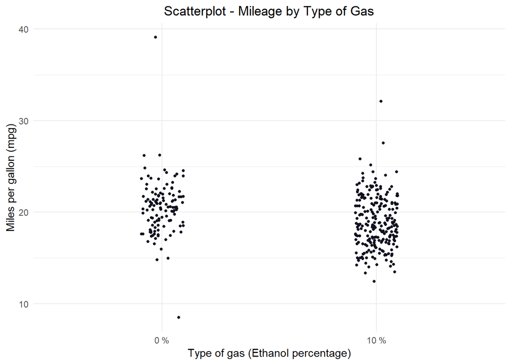

## Results

Because the explanatory variable (Type of gas) is categorical, & the residuals have a skewed distribution, we will fit a log-linear regression model for the logarithm of miles per gallon on type of gas. The structure of the logarthimic regression model is
$$log(Y_i)=\beta_0+\beta_1X_i+\epsilon_i$$
where $Y_i$ is miles per gallon, $X_i$ is the type of gas (0% = 0, 10% = 1), & $\epsilon_i$ is the error.

Diagnostic plots are included below to help evaluate model assumptions.

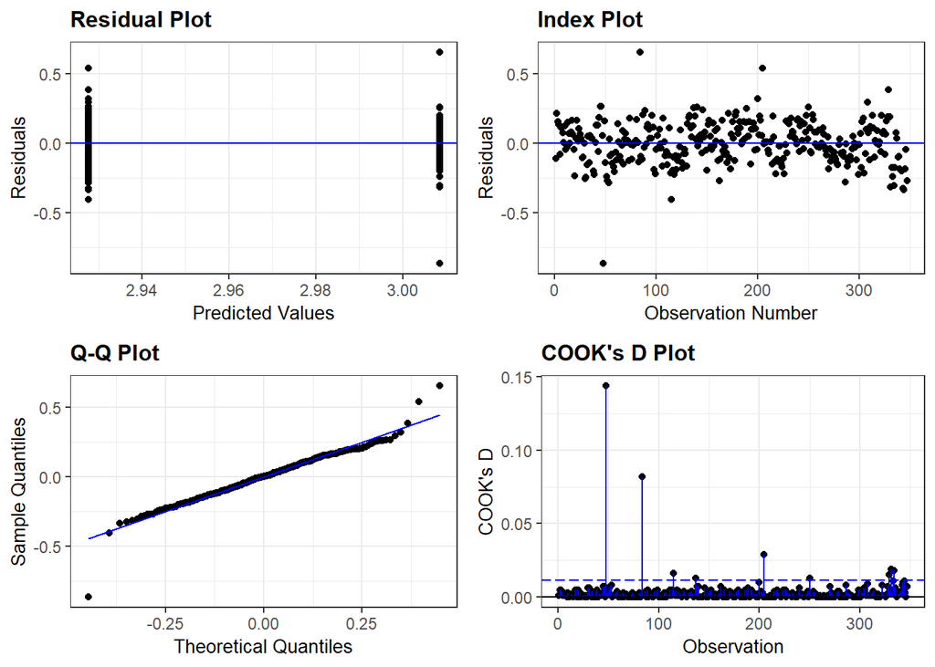

Below is a plot of the estimated mean miles per gallon with 95% confidence intervals. As seen with the original data, mpg generally decreases a slight amount when the type of gas has 10% ethanol compared to no ethanol.

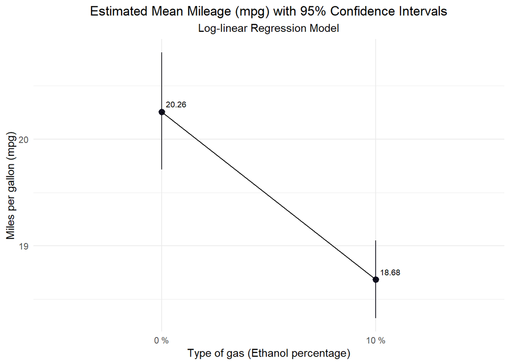

## Discussion

Using data obtained from car trips made on Professor Niemi’s 2011 Toyota Sienna, recording number of miles and type of gas at each gas fill up, we performed simple linear regression analysis, modelling the logarithm of miles per gallon on type of gas. We found that when comparing the two types of gas, gas with 10% ethanol is associated with a generally lower mileage than for gas with no ethanol.

Because the type of gas selected at each gas fill up was not randomized, our results on the effect of type of gas on mileage cannot be interpreted as causal. Since the trips made on Professor Niemi’s 2011 Toyota Sienna are not a random sample from any population, we cannot justifiably extend these results to a larger population.